# Combined Data Markup

Ben Gaiser & Jeremy Russell

10/7/2016

### Installing packages

```r
packages <- c('repmis', 'knitr', 'rmarkdown', 'Hmisc', 'ggplot2', 'pastecs', 'RCurl')
for (p in packages) {
  if (p %in% installed.packages()) require(p, character.only=TRUE)
  else {
    install.packages(p)
    require(p, character.only=TRUE)
  }
}
```

### Creating a BibTex file

```r
repmis::LoadandCite(packages, file = 'RpackageCitations.bib')
```

### Setting our working directory

```r
wrkdir <- c('C:/Users/Benji/Desktop/Statistics/Git/Repositories/data/alcohol-consumption',
            '~/Hertie School/Fall 2016/CollaborativeSocialScienceDataAnalysis/CSSR')
repmis::set_valid_wd(wrkdir)
```

### Removing from global environment for better readability

```r
rm(packages, p, wrkdir)
```

### Loading the data frames:

###### Alcohol Consumption data set is from fivethirtyeight (https://github.com/fivethirtyeight/data). Swiss is a core R data frame

```r
AlcoholConsumption <- read.csv(text = getURL("https://raw.githubusercontent.com/fivethirtyeight/data/master/alcohol-consumption/drinks.csv"))
swiss <- as.data.frame(swiss)
```

### Executing the Data Gathering File

```r
source('https://raw.githubusercontent.com/BenjaminGaiser/CSSR/master/DataGathering.R')
```

### Data Frame 1: Alcohol Consumption

###### Units: Avergae serving sizes per person

###### Source: 538 from World Health Organisation, Global Information System on Alcohol and Health (GISAH), 2010

###### Variables of interest:

###### Independent Variable X: beer servings

###### Dependent Variable Y: total litres of pure alcohol

### What the data look like - Initial Descriptive Statistics

```r
summary(AlcoholConsumption)
```

```
##    country          beer_servings   spirit_servings  wine_servings
##  Length:193         Min.   :  0.0   Min.   :  0.00   Min.   :  0.00
##  Class :character   1st Qu.: 20.0   1st Qu.:  4.00   1st Qu.:  1.00
##  Mode  :character   Median : 76.0   Median : 56.00   Median :  8.00
##                     Mean   :106.2   Mean   : 80.99   Mean   : 49.45
##                     3rd Qu.:188.0   3rd Qu.:128.00   3rd Qu.: 59.00
##                     Max.   :376.0   Max.   :438.00   Max.   :370.00
##  total_litres_of_pure_alcohol
##  Min.   : 0.000
##  1st Qu.: 1.300
##  Median : 4.200
##  Mean   : 4.717
##  3rd Qu.: 7.200
##  Max.   :14.400
```

```r
describe(AlcoholConsumption)
```

```
## AlcoholConsumption
##
##  5  Variables      193  Observations
## ---------------------------------------------------------------------------
## country
##       n missing  unique
##     193       0     193
##
## lowest : Afghanistan Albania     Algeria     Andorra     Angola
## highest: Venezuela   Vietnam     Yemen       Zambia      Zimbabwe
## ---------------------------------------------------------------------------
## beer_servings
##       n missing  unique    Info    Mean     .05     .10     .25     .50
##     193       0     130       1   106.2     0.0     2.2    20.0    76.0
##     .75     .90     .95
##   188.0   259.0   295.8
##
## lowest :   0   1   2   3   5, highest: 343 346 347 361 376
## ---------------------------------------------------------------------------
## spirit_servings
##       n missing  unique    Info    Mean     .05     .10     .25     .50
##     193       0     109       1   80.99     0.0     0.0     4.0    56.0
##     .75     .90     .95
##   128.0   204.4   252.8
##
## lowest :   0   1   2   3   4, highest: 302 315 326 373 438
## ---------------------------------------------------------------------------
## wine_servings
##       n missing  unique    Info    Mean     .05     .10     .25     .50
##     193       0      79    0.99   49.45     0.0     0.0     1.0     8.0
##     .75     .90     .95
##    59.0   183.0   225.8
##
## lowest :   0   1   2   3   4, highest: 278 280 312 339 370
## ---------------------------------------------------------------------------
## total_litres_of_pure_alcohol
##       n missing  unique    Info    Mean     .05     .10     .25     .50
##     193       0      90       1   4.717    0.00    0.12    1.30    4.20
##     .75     .90     .95
##    7.20   10.40   11.34
##
## lowest :  0.0  0.1  0.2  0.3  0.4, highest: 11.8 11.9 12.4 12.9 14.4
## ---------------------------------------------------------------------------
```

### Who drinks the most in total litres of pure alcohol?

```r
which.max(AlcoholConsumption$total_litres_of_pure_alcohol)
```

```
## [1] 16
```

### The answer is row 16, i.e. Belarus

```r
head(AlcoholConsumption[16,])
```

```
##    country beer_servings spirit_servings wine_servings
## 16 Belarus           142             373            42
##    total_litres_of_pure_alcohol
## 16                         14.4
```

### Who drinks the least in total litres of pure alcohol?

```r
which.min(AlcoholConsumption$total_litres_of_pure_alcohol)
```

```
## [1] 1
```

### The answer is row 1, i.e. Afghanistan

```r
head(AlcoholConsumption[1,])
```

```
##       country beer_servings spirit_servings wine_servings
## 1 Afghanistan             0               0             0
##   total_litres_of_pure_alcohol
## 1                            0
```

### Hypothesis: Beer is the main driver of total litres of pure alcohol consumed per country

### Looking at the correlation to see if hypothesis is accurate

```r
cor(AlcoholConsumption$beer_servings, AlcoholConsumption$total_litres_of_pure_alcohol)    # 0.84
```

```
## [1] 0.8358386
```

```r
cor(AlcoholConsumption$wine_servings, AlcoholConsumption$total_litres_of_pure_alcohol)    # 0.67
```

```
## [1] 0.6675983
```

```r
cor(AlcoholConsumption$spirit_servings, AlcoholConsumption$total_litres_of_pure_alcohol)  # 0.65
```

```
## [1] 0.6549682
```

### It seems that beer servings are most closely correlated to total litres of pure alcohol

### Plotting our findings in a scatterplot with a line of best fit and the 95% confidence interval

### Step 1: Creating a function for plotting a ggplot

```r
ggplotRegAlcCons <- function(fit){
  ggplot(AlcoholConsumption, aes(beer_servings, total_litres_of_pure_alcohol)) +
    geom_point(colour = 'blue') +
    stat_smooth(method = 'lm', col = 'red', size=0.75) +
    labs(title = paste('Adj R2 = ',signif(summary(fit)$adj.r.squared, 3),
                       'Intercept =',signif(fit$coef[[1]],3 ),
                       ' Slope =',signif(fit$coef[[2]], 1),
                       ' P =',signif(summary(fit)$coef[2,4], 2)))
}
```

### Step 2: Running the linear regression for the line of best fit

```r
FitOfData <- lm(total_litres_of_pure_alcohol ~ beer_servings, data=AlcoholConsumption)
```

### Step 3: Plotting the graph

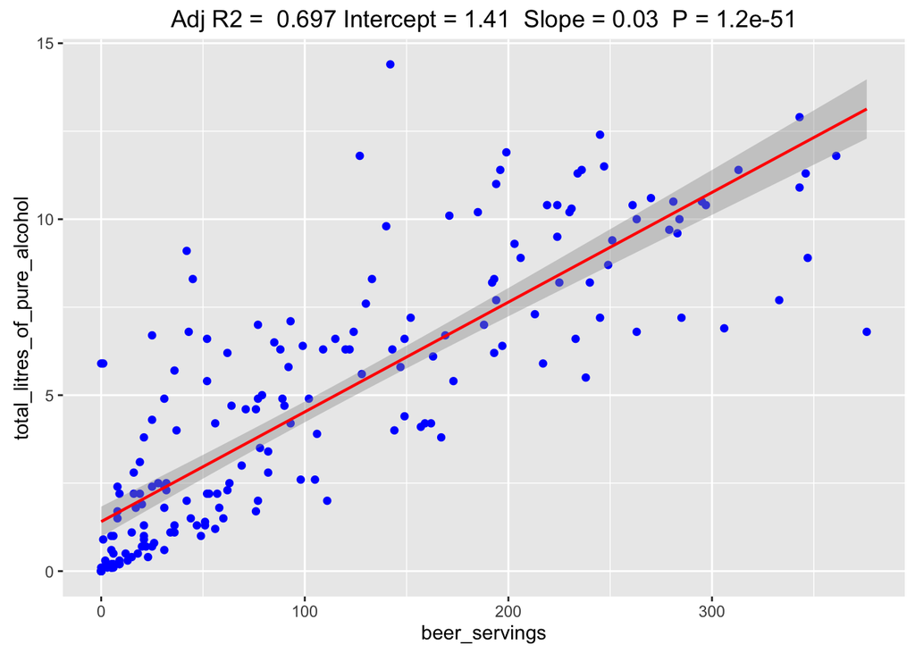

```r
ggplotRegAlcCons(FitOfData)
```

### Analyzing five countries of interest to see how they differ in their beer servings values

### Finding Germany, USA, South Africa, China and Australia

```r
which(grepl('Germany', AlcoholConsumption$country)) # row 66
```

```
## [1] 66
```

```r
which(grepl('USA', AlcoholConsumption$country)) # row 185
```

```
## [1] 185
```

```r
which(grepl('South Africa', AlcoholConsumption$country)) # row 160
```

```
## [1] 160
```

```r
which(grepl('China', AlcoholConsumption$country)) # row 37
```

```
## [1] 37
```

```r
which(grepl('Australia', AlcoholConsumption$country)) # row 9
```

```
## [1] 9
```

### Subsetting the Data ‘AlcoholConsumption’ for ease of commanding

```r
SubsetOfFiveCountries <- AlcoholConsumption[c(9, 37, 66, 160, 185),]
```

### Plotting our findings in a Scatterplot, we see that Germany drinks most out of the five countries on both variables

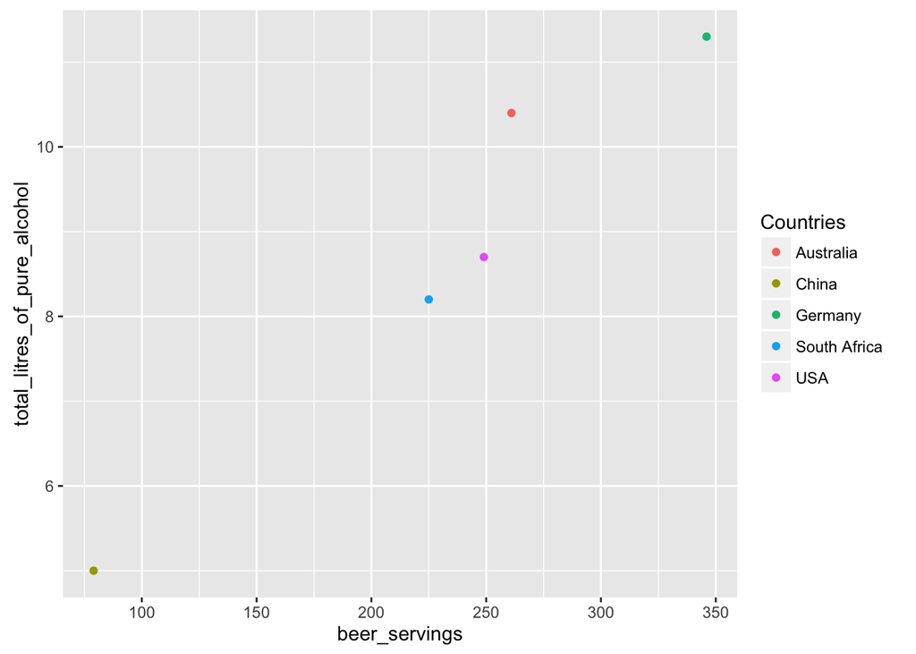

```r
ggplot(SubsetOfFiveCountries,
       aes(beer_servings, total_litres_of_pure_alcohol)) +
  geom_point(aes(colour = factor(country))) +
  scale_colour_discrete(name='Countries')
```

### Hypothesis: Catholics have a higher fertility rate than Protestants

### A closer look at the initial descriptive statistics of our variables of interest

```r
describe(swiss$Fertility)
```

```
## swiss$Fertility
##       n missing  unique    Info    Mean     .05     .10     .25     .50
##      47       0      46       1   70.14   47.58   56.24   64.70   70.40
##     .75     .90     .95
##   78.45   84.60   90.67
##
## lowest : 35.0 42.8 44.7 54.3 55.7, highest: 85.8 87.1 92.2 92.4 92.5
```

```r
describe(swiss$Catholic)
```

```
## swiss$Catholic
##       n missing  unique    Info    Mean     .05     .10     .25     .50
##      47       0      46       1   41.14   2.448   2.832   5.195  15.140
##     .75     .90     .95
##  93.125  99.000  99.614
##
## lowest :   2.15   2.27   2.40   2.56   2.82
## highest:  99.06  99.46  99.68  99.71 100.00
```

```r
var(swiss$Fertility)
```

```
## [1] 156.0425
```

```r
var(swiss$Catholic)
```

```
## [1] 1739.295
```

```r
sd(swiss$Fertility)
```

```
## [1] 12.4917
```

```r
sd(swiss$Catholic)
```

```
## [1] 41.70485
```

### Catholic shows high variance and standard deviation for a continuous variable of between 0 and 100

### Plotting both variables to see their relationship

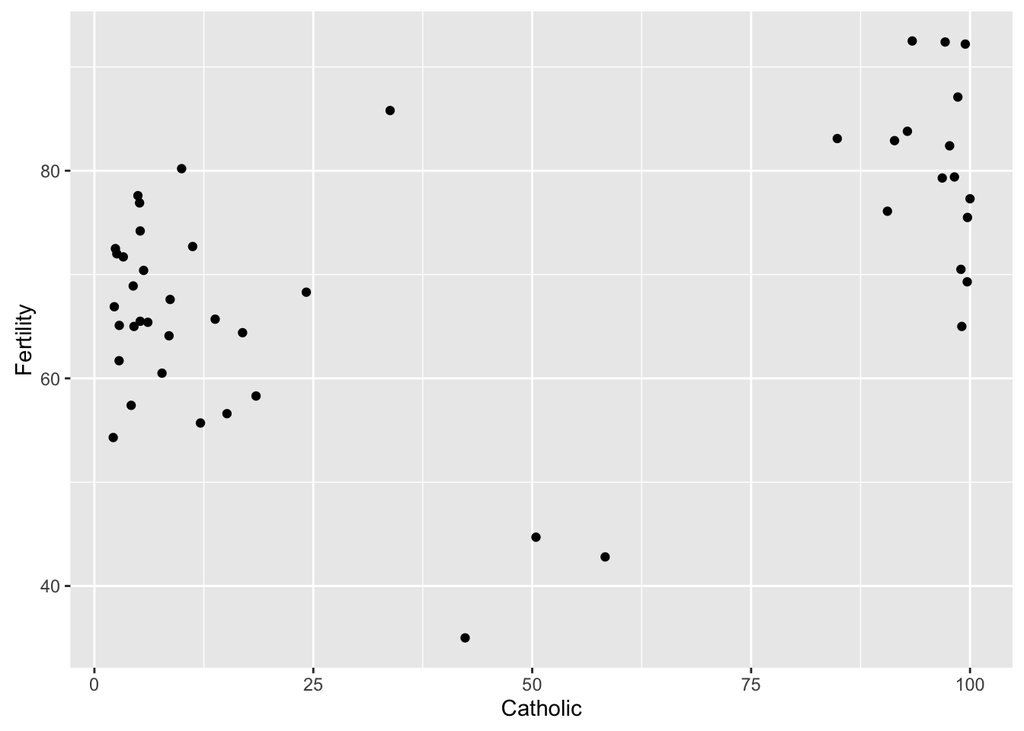

```r
ggplot(swiss, aes(Catholic, Fertility)) + geom_point()
```

### Plot fertility and Catholic with ggplot

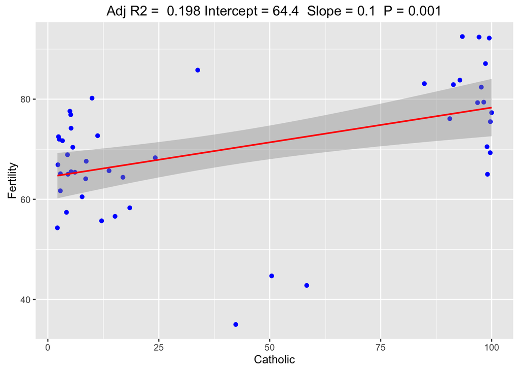

```r
ggplotRegSwiss <- function(fit){
  ggplot(swiss, aes(Catholic, Fertility)) +
    geom_point(colour = 'blue') +
    stat_smooth(method = 'lm', col = 'red', size=0.75) +
    labs(title = paste('Adj R2 = ',signif(summary(fit)$adj.r.squared, 3),
                       'Intercept =',signif(fit$coef[[1]],3 ),
                       ' Slope =',signif(fit$coef[[2]], 1),
                       ' P =',signif(summary(fit)$coef[2,4], 2)))
}
FitOfDataSwiss <- lm(Fertility ~ Catholic, data = swiss)
ggplotRegSwiss(FitOfDataSwiss)
```

#### Despite outliers, this is still a significant relationship, explaining 20 % of the variance (R-value)

### Which cantons are neither mostly Protestant nor mostly Catholic?

#### Step 1: Creating a factor variable with four different groups

```r
swiss$CatholicCat <- cut(swiss$Catholic, seq(0, 100, 25))
```

#### Step 2: Changing the factor variable into a character variable for renaming the rownames

```r
swiss$CatholicCat <- as.character(swiss$CatholicCat)
```

#### Step 3: Renaming the rownames

```r
swiss$CatholicCat[swiss$CatholicCat=='(0,25]'] <- 'Protestant'
swiss$CatholicCat[swiss$CatholicCat=='(25,50]'] <- 'Protestant to Catholic'
swiss$CatholicCat[swiss$CatholicCat=='(50,75]'] <- 'Catholic to Protestant'
swiss$CatholicCat[swiss$CatholicCat=='(75,100]'] <- 'Catholic'
```

#### Step 4: Finding the cantons which are ‘Protestant to Catholic’ and ‘Catholic to Protestant’

```r
which(grepl('Protestant to Catholic', swiss$CatholicCat)) # 4 and 45
```

```
## [1]  4 45
```

```r
which(grepl('Catholic to Protestant', swiss$CatholicCat)) # 46 and 47
```

```
## [1] 46 47
```

#### Step 5: Searching the names

```r
swiss[c(4,45:47),]
```

```
##              Fertility Agriculture Examination Education Catholic
## Moutier           85.8        36.5          12         7    33.77
## V. De Geneve      35.0         1.2          37        53    42.34
## Rive Droite       44.7        46.6          16        29    50.43
## Rive Gauche       42.8        27.7          22        29    58.33
##              Infant.Mortality            CatholicCat
## Moutier                  20.3 Protestant to Catholic
## V. De Geneve             18.0 Protestant to Catholic
## Rive Droite              18.2 Catholic to Protestant
## Rive Gauche              19.3 Catholic to Protestant
```

### Moutier, V. De Geneve, Rive Droite and Rive Gauce are the only cantons where there is at least a third of the population that does not belong to the majority religion